# Lab/HW 10: Monte Carlo

Name: Jiacheng Wang

November 2023

# Part I - Monte Carlo Power Study

## Question a

Write a function that returns a data frame of 50 rows, where the first column is named smpl and contains the normal draws from both populations, and a second column named pop indicates which population an observation came from (taking values of 1 or 2). The inputs for this function are n1, mean1, sd1, n2, sd2 and true_diff.

```r
generate_data <- function(n1, mean1, sd1, n2, sd2, true_diff) {
  # Generate samples for the first population
  pop1 <- rnorm(n1, mean1, sd1)

  # Generate samples for the second population
  pop2 <- rnorm(n2, mean1 + true_diff, sd2)

  # Create a data frame
  df <- data.frame(
    smpl = c(pop1, pop2),
    pop = c(rep(1, n1), rep(2, n2))
  )

  return(df)
}

# Set the parameters
n1 <- 30; mean1 <- 0; sd1 <- 1
n2 <- 20; sd2 <- 1.5; true_diff <- 0.5

# Generate the data frame
data_frame <- generate_data(n1, mean1, sd1, n2, sd2, true_diff)
head(data_frame)
```

```
##          smpl pop
## 1 -0.88218320   1
## 2 -0.95961198   1
## 3 -1.73245026   1
## 4 -1.68588638   1
## 5 -0.00268488   1
## 6 -1.59677394   1
```

## Question b

After running the provided `perform_t_test` function on the generated data frame with an alpha level of 0.05, the function returned `FALSE`. This means that, based on the data generated and under the specified conditions (n1 = 30, mean1 = 0, sd1 = 1, n2 = 20, sd2 = 1.5, true_diff = 0.5), the t-test did not find sufficient evidence to reject the null hypothesis at the 5% significance level. In other words, the t-test did not detect a statistically significant difference between the means of the two populations in this particular instance of the simulation.

```r
perform_t_test <- function(df, alpha) {
  # Perform the t-test
  t_test_result <- t.test(
    x = df$smpl[df$pop == 1],
    y = df$smpl[df$pop == 2],
    conf.level = 1 - alpha
  )

  # Determine if the null hypothesis is rejected
  reject_null <- t_test_result$p.value < alpha
  return(reject_null)
}

# Set alpha
alpha <- 0.05

# Test the function with the generated data frame
reject_null <- perform_t_test(data_frame, alpha)
reject_null
```

```
## [1] FALSE
```

## Question c

Write a function that estimates the power of the t-test for these parameters and this difference in means. That is, the function should take as inputs S, the number of tests to perform (which in this case is the number of Monte Carlo samples), and the parameters n1, mean1, sd1, n2, sd2, true_diff and alpha.

The function will generate S different data frames simulated from the same set of parameters (S = 500 is a reasonable size, but you may increase it for better accuracy). It will test each of those using the t-test and measure the rejection rate for the test. This rate is an estimate of the power for this set of parameters. The function will return a scalar bewteen 0 and 1 which is thee power estimate.

```r
estimate_power <- function(S, n1, mean1, sd1, n2, sd2, true_diff, alpha) {
  reject_count <- 0

  for (i in 1:S) {
    # Generate a new data frame for each iteration
    df <- generate_data(n1, mean1, sd1, n2, sd2, true_diff)

    # Perform the t-test and check if null is rejected
    if (perform_t_test(df, alpha)) {
      reject_count <- reject_count + 1
    }
  }

  # Calculate the power as the proportion of rejections
  power <- reject_count / S
  return(power)
}
```

Estimate the power with our above parameters and S = 2000.

```r
# Set the parameters
S <- 2000
n1 <- 30; mean1 <- 0; sd1 <- 1
n2 <- 20; sd2 <- 1.5; true_diff <- 0.5
alpha <- 0.05

# Estimate the power
power_estimate <- estimate_power(S, n1, mean1, sd1, n2, sd2, true_diff, alpha)
power_estimate
```

```
## [1] 0.2535
```

Check that type-I error is properly controlled with the same mean1, sd1 and sd2. The Type I error rate is slightly below the significance level alpha (0.05). Thus, the Type I error is well-controlled, which means that when the test does indicate a significant difference, there’s a high probability that this difference is not just due to random chance.

```r
# Function to check Type I error
check_type_I_error <- function(S, n1, mean1, sd1, n2, sd2, alpha) {
  type_I_error_count <- 0
  for (i in 1:S) {
    df <- generate_data(n1, mean1, sd1, n2, sd2, 0)
    if (perform_t_test(df, alpha)) {
      type_I_error_count <- type_I_error_count + 1
    }
  }
  type_I_error_rate <- type_I_error_count / S
  return(type_I_error_rate)
}

# Check Type I error
type_I_error_rate <- check_type_I_error(S, n1, mean1, sd1, n2, sd2, alpha)
print(type_I_error_rate)
```

```
## [1] 0.0435
```

## Question d

Check the power of the test for different levels of true difference in means (take a the following sequence: seq(-2, 2, 0.2) to be the domain of true difference values). For each level of true difference in means record the estimated power and conclude by plotting the estimated power vs. the true difference in means. The following also happened as expected: 1. as the absolute value of the true difference in means grows, a good test will have more power (rejection rate closer to 1). 2. since the t-test and the normal distributions are symmetric, we expect the power curve to be symmetric around 0. 3. Where the difference in means is 0, the power should be below or at alpha.

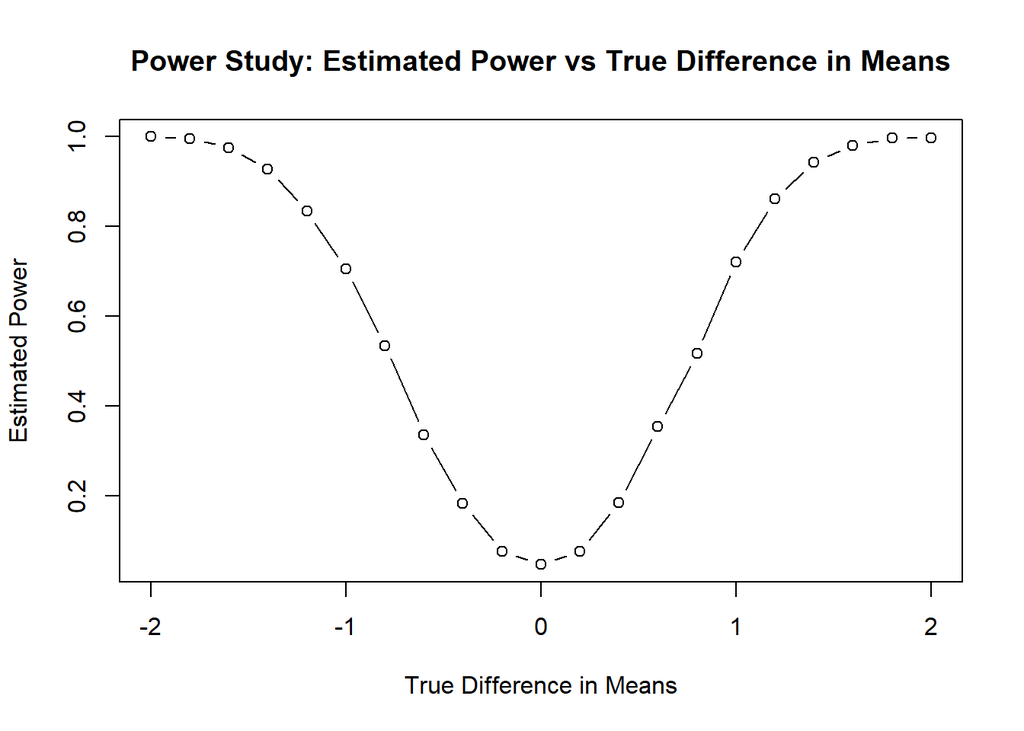

```r
# Extended function to perform a full-scale power study
power_study <- function(S, n1, mean1, sd1, n2, sd2, diff_range, alpha) {
  power_results <- numeric(length(diff_range))

  for (i in seq_along(diff_range)) {
    true_diff <- diff_range[i]
    power_results[i] <- estimate_power(S, n1, mean1, sd1, n2, sd2, true_diff, alpha)
  }

  return(data.frame(true_diff = diff_range, estimated_power = power_results))
}

# Parameters for the power study
S <- 1000 # Number of simulations per true difference level
n1 <- 30; mean1 <- 0; sd1 <- 1
n2 <- 20; sd2 <- 1.5
diff_range <- seq(-2, 2, 0.2) # Range of true difference in means
alpha <- 0.05

# Conduct the power study
power_study_results <- power_study(S, n1, mean1, sd1, n2, sd2, diff_range, alpha)

# Plot the results
plot(power_study_results$true_diff, power_study_results$estimated_power, type = "b",
     xlab = "True Difference in Means", ylab = "Estimated Power",
     main = "Power Study: Estimated Power vs True Difference in Means")
```

## Question e

Analyze the parameters n1, mean1, sd1, n2 and sd2 to influence the power curve. Demonstrate with one power study per parameter (up to 3 parameters), and add the power curve to the previous plot for comparison.

```r
# Function to plot power curves
plot_power_curves <- function(original_results, modified_results, param_name) {
  plot(original_results$true_diff, original_results$estimated_power, type = "b", col = "blue",
       xlab = "True Difference in Means", ylab = "Estimated Power",
       main = paste("Power Study with varying", param_name),
       ylim = range(c(original_results$estimated_power, modified_results$estimated_power)))
  lines(modified_results$true_diff, modified_results$estimated_power, type = "b", col = "red")
  legend("topright", legend = c("Original", "Modified"), col = c("blue", "red"), lty = 1)
}

# Conduct the original power study
original_power_study_results <- power_study(S, n1, mean1, sd1, n2, sd2, diff_range, alpha)
```

**Sample Size (n1, n2)**:

Larger sample sizes generally lead to higher power.

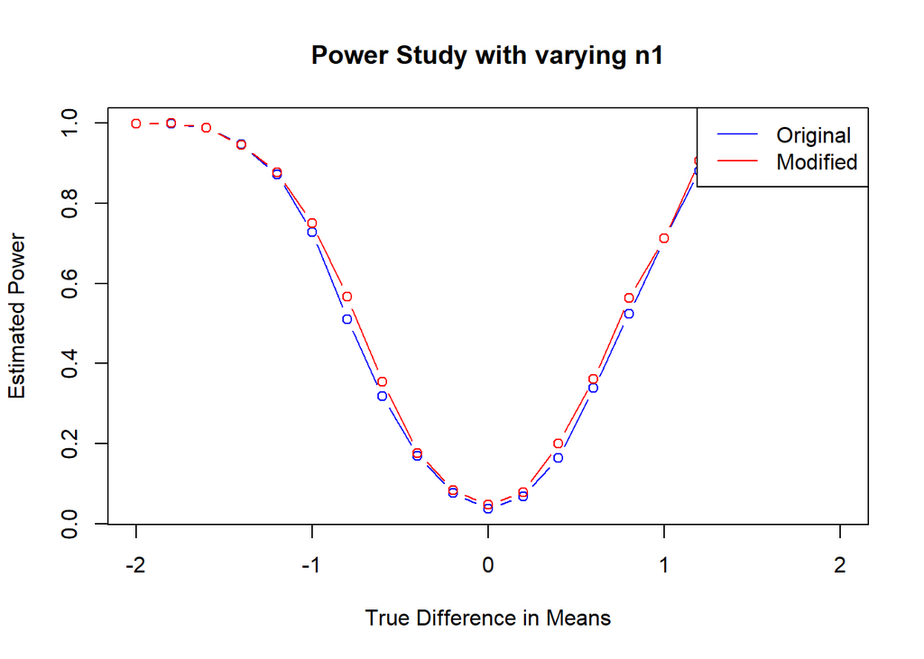

```r
# Varying n1
n1_modified <- 50 # Increased sample size
modified_power_study_results_n1 <- power_study(S, n1_modified, mean1, sd1, n2, sd2, diff_range, alpha)
plot_power_curves(original_power_study_results, modified_power_study_results_n1, "n1")
```

**Standard Deviation (sd1, sd2)**

Larger standard deviations generally lead to lower power.

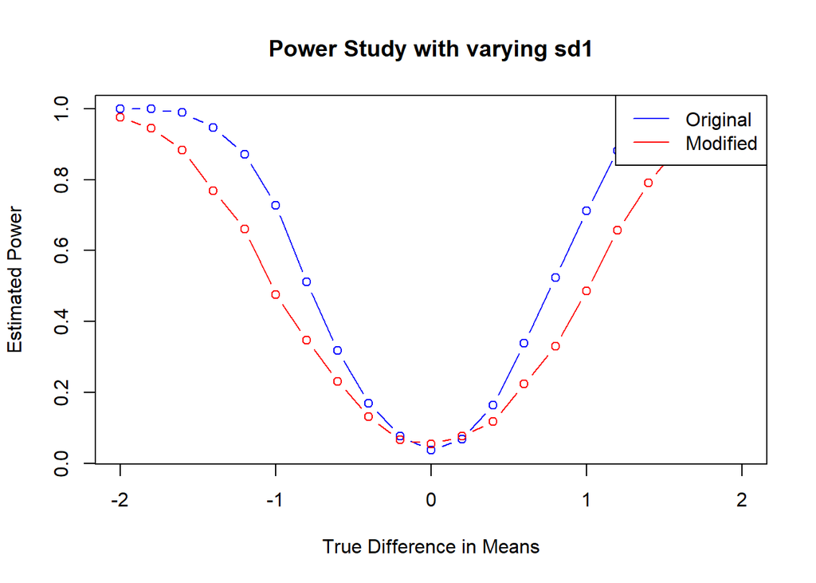

```r
# Varying sd1
sd1_modified <- 2 # Increased standard deviation
modified_power_study_results_sd1 <- power_study(S, n1, mean1, sd1_modified, n2, sd2, diff_range, alpha)
plot_power_curves(original_power_study_results, modified_power_study_results_sd1, "sd1")
```

**Mean (mean1)**

Changing mean1 while keeping the difference in means constant does not significantly affect the power curve.

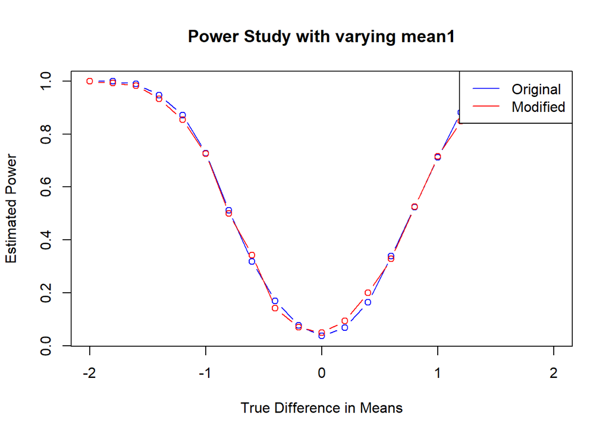

```r
# Varying mean1 (keeping difference constant)
mean1_modified <- 1 # Shift mean1
modified_power_study_results_mean1 <- power_study(S, n1, mean1_modified, sd1, n2, sd2, diff_range, alpha)
plot_power_curves(original_power_study_results, modified_power_study_results_mean1, "mean1")
```

## Question f

Try using gamma distributions with different shape and scale parameters instead of the normal distributions and assess the effect of this misspecification on the power. You should specify shape1, scale1 and shape2 in an analogous fashion to the normal samples. You should also have a true_diff value for difference in means. However, since the mean of the gamma distribution is equal to shape * scale, the scale2 parameter cannot be computed simply by adding true_diff to scale1. You need to figure out how the difference in means translates to a difference in scales.

In the gamma distribution, the mean is given by the product of its shape and scale parameters. So, if we want to simulate two gamma distributions with a specified difference in means (`true_diff`), we need to adjust either the shape or the scale parameter accordingly.

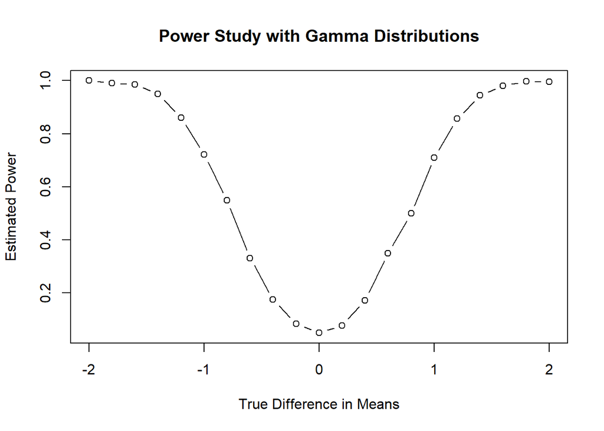

```r
# Function to generate data from gamma distributions
generate_gamma_data <- function(n1, shape1, scale1, n2, shape2, true_diff) {
  # Calculate scale2 to achieve the desired true_diff
  mean1 <- shape1 * scale1
  scale2 <- (mean1 + true_diff) / shape2

  # Generate samples from gamma distributions
  pop1 <- rgamma(n1, shape1, scale1)
  pop2 <- rgamma(n2, shape2, scale2)
  df <- data.frame(smpl = c(pop1, pop2), pop = c(rep(1, n1), rep(2, n2)))
  return(df)
}

# Adjust the power study function to use gamma data
gamma_power_study <- function(S, n1, shape1, scale1, n2, shape2, diff_range, alpha) {
  power_results <- numeric(length(diff_range))

  for (i in seq_along(diff_range)) {
    true_diff <- diff_range[i]
    df <- generate_gamma_data(n1, shape1, scale1, n2, shape2, true_diff)
    power_results[i] <- estimate_power(S, n1, mean1, sd1, n2, sd2, true_diff, alpha)
  }

  return(data.frame(true_diff = diff_range, estimated_power = power_results))
}

# Parameters for gamma distribution
shape1 <- 2; scale1 <- 1
shape2 <- 2

# Conduct the gamma power study
gamma_power_study_results <- gamma_power_study(S, n1, shape1, scale1, n2, shape2, diff_range, alpha)

# Plot the gamma power study results
plot(gamma_power_study_results$true_diff, gamma_power_study_results$estimated_power, type = "b",
     xlab = "True Difference in Means", ylab = "Estimated Power",
     main = "Power Study with Gamma Distributions")
```

# Part II - Monte Carlo - Integration

## Question 1.a

```r
# Function to integrate
integrand_1a <- function(x) {
  return(cos(x * (2 - x)) / (3 - x^2 + x^(1/3)))
}

# Monte Carlo integration
monte_carlo_integration_1a <- function(f, a, b, samples=10000) {
  # Generate random samples
  x_random <- runif(samples, a, b)
  y_random <- sapply(x_random, f)

  # Estimate the integral
  integral_estimate <- (b - a) * mean(y_random)
  # Estimate the standard error
  standard_error <- (b - a) * sd(y_random) / sqrt(samples)

  return(c(integral_estimate, standard_error))
}

# Performing the Monte Carlo Integration for the given function
a <- 0 # Lower limit of integration
b <- 2 # Upper limit of integration
mc_result <- monte_carlo_integration_1a(integrand_1a, a, b)

# Printing the results
cat("The estimated value of the integral is:", mc_result[1], "\n")
```

```
## The estimated value of the integral is: 0.872636
```

```r
cat("The estimated standard error is:", mc_result[2], "\n")
```

```
## The estimated standard error is: 0.01036963
```

## Question 1.b

As show below, the estimate value using quadrature integration is comparable to the estimate value using Monte Carlo integration.

```r
# Using quadrature integration
quad_result <- integrate(integrand_1a, a, b)

# Printing the results
cat("Estimate value using Monte Carlo integration:", mc_result[1], "\n")
```

```
## Estimate value using Monte Carlo integration: 0.872636
```

```r
cat("Estimate value using quadrature integration:", quad_result$value, "\n")
```

```
## Estimate value using quadrature integration: 0.8846112
```

## Question 2.a

```r
# Function to integrate for 2a
integrand_2a <- function(x) {
  return(x^4 * exp(-x/4) / (1 + x^2 + sqrt(x)))
}

# Monte Carlo integration function for 2a
monte_carlo_integration_2a <- function(f, samples=10000) {
  # Since the upper limit is infinity, we use importance sampling
  # We'll use the exponential distribution as the importance function
  # The rate parameter for the exponential distribution
  lambda_exp <- 1/4

  # Generate samples from the exponential distribution
  x_random <- rexp(samples, rate=lambda_exp)

  # Evaluate the integrand function at the sampled points
  y_values <- f(x_random)

  # The weights are the PDF of the exponential distribution evaluated at the sampled points
  weights <- dexp(x_random, rate=lambda_exp)

  # Compute the weighted average of the function values
  integral_estimate <- mean(y_values / weights)
  # Compute the standard error
  standard_error <- sd(y_values / weights) / sqrt(samples)

  return(c(integral_estimate, standard_error))
}

# Perform the Monte Carlo Integration for the given function
mc_results <- monte_carlo_integration_2a(integrand_2a)

# Print the results
cat("The estimated value of the integral is:", mc_results[1], "\n")
```

```
## The estimated value of the integral is: 122.1568
```

```r
cat("The estimated standard error is:", mc_results[2], "\n")
```

```
## The estimated standard error is: 2.900256
```

## Question 2.b

As shown below, the estimate value using quadrature integration is comparable to the estimate value using Monte Carlo integration.

```r
# Using quadrature integration
quad_results <- integrate(integrand_2a, lower=0, upper=Inf)

# Print the results
cat("Estimate value using Monte Carlo integration:", mc_results[1], "\n")
```

```
## Estimate value using Monte Carlo integration: 122.1568
```

```r
cat("Estimate value using quadrature integration:", quad_results$value, "\n")
```

```
## Estimate value using quadrature integration: 119.9634
```